# filter_genotypes_and_variants_wecare_only

started: Alexey Larionov, 01Mar2016  
last updated: Alexey Larionov, 26Aug2017

# Summary

gq 20 filter is set arbitrary; however, it is consistent with what some othersis do  
(e.g. see Carson BMC Bioinformatics. 2014 15:125).

Call rate 85% was set for consistency with missing_cutoff default value (0.15) in SKAT function

It was discussed with DC whether to filter cases by call rate per case. There was ~3 cases with low coverage (<20) and low call rates (<50%). We desided to keep such cases because their retained genotypes still passed all filters.

Input data: 343,824 vars x 512 cases  
Output data: 247,454 vars x 512 cases

# start_section

```r
# Time stamp
Sys.time()
```

```
## [1] "2017-08-26 20:29:48 BST"
```

```r
# Clenan-up
rm(list=ls())

# Libraries location
.libPaths("/home/alarionov/R/my_libs_r3.4.1/")

# Base folder
library(knitr)
base_folder="/analysis/mtgroup_share/users/alexey/wecare_only_08.17"
opts_knit$set(root.dir = base_folder)
#setwd(base_folder)

# Thresholds for genotypes
min.gq <- 20
max.dp <- 500

# Variants call ratethreshold
min.call.rate <- 0.85
```

# load_data

```r
#base_folder="/analysis/mtgroup_share/users/alexey/wecare_only_08.17"
load(paste(base_folder, "results", "r01_read_and_clean_data_wecare_only.RData", sep="/"))
```

# check_data

```r
dim(gt.mx)
```

```
## [1] 343824    512
```

```r
class(gt.mx)
```

```
## [1] "matrix"
```

```r
gt.mx[1:5,1:5]
```

```
##              P1_A01 P1_A02 P1_A03 P1_A04 P1_A05
## Var000000001      0      1      0      0      0
## Var000000002      0      0      0      0      0
## Var000000003      0     NA      0      0      0
## Var000000004      0     NA      0      0      0
## Var000000005      0      0      0      0      0
```

```r
dim(gq.mx)
```

```
## [1] 343824    512
```

```r
class(gq.mx)
```

```
## [1] "matrix"
```

```r
gq.mx[1:5,1:5]
```

```
##              P1_A01 P1_A02 P1_A03 P1_A04 P1_A05
## Var000000001     99     99     99     99     99
## Var000000002     99     72     99     99     81
## Var000000003     51     NA      3     63     15
## Var000000004      3     NA      6     48      9
## Var000000005     15      9      6     24      6
```

```r
dim(dp.mx)
```

```
## [1] 343824    512
```

```r
class(dp.mx)
```

```
## [1] "matrix"
```

```r
dp.mx[1:5,1:5]
```

```
##              P1_A01 P1_A02 P1_A03 P1_A04 P1_A05
## Var000000001     47    151     34     53     41
## Var000000002     43     26     43     42     29
## Var000000003     18      0      1     21      5
## Var000000004      3      0      2     17      3
## Var000000005      6      3      2      8      2
```

```r
dim(covar.df)
```

```
## [1] 498  34
```

```r
str(covar.df)
```

```
## 'data.frame':    498 obs. of  34 variables:
##  $ Subject_ID      : int  200054 200491 200565 200698 200958 201046 201558 201921 202026 202236 ...
##  $ setno           : int  382125 204356 360683 226881 357431 374980 201558 201921 213991 385058 ...
##  $ cc              : int  0 0 0 0 0 0 1 1 0 0 ...
##  $ chemo           : int  1 1 0 0 1 1 1 1 1 1 ...
##  $ hormone         : int  0 1 1 0 1 0 0 1 1 0 ...
##  $ chemo_hormone   : Factor w/ 5 levels "","both","chem",..: 3 2 4 5 2 3 3 2 2 3 ...
##  $ chemo_self_mra  : int  1 1 0 0 1 1 1 1 1 1 ...
##  $ hormone_self_mra: int  0 1 1 0 1 0 0 1 1 0 ...
##  $ treatment       : int  1 1 1 0 1 1 1 1 1 1 ...
##  $ ID              : int  2 6 7 9 11 12 16 22 24 26 ...
##  $ labid           : Factor w/ 498 levels "id200054","id200491",..: 1 2 3 4 5 6 7 8 9 10 ...
##  $ status          : int  0 0 0 0 0 0 1 1 0 0 ...
##  $ status2         : int  0 0 0 0 0 0 1 1 0 0 ...
##  $ offset          : num  6.41 5.82 5.61 4.03 4.77 ...
```

[output cut: 20 more lines]

```r
covar.df[1:5,1:5]
```

```
##   Subject_ID  setno cc chemo hormone
## 1     200054 382125  0     1       0
## 2     200491 204356  0     1       1
## 3     200565 360683  0     0       1
## 4     200698 226881  0     0       0
## 5     200958 357431  0     1       1
```

```r
dim(samples.df)
```

```
## [1] 512   4
```

```r
str(samples.df)
```

```
## 'data.frame':    512 obs. of  4 variables:
##  $ wes_id   : Factor w/ 512 levels "P1_A01","P1_A02",..: 1 2 3 4 5 6 7 8 9 10 ...
##  $ gwas_id  : Factor w/ 510 levels "id200054","id200491",..: 14 405 315 264 67 121 326 251 281 141 ...
##  $ merged_id: Factor w/ 512 levels "P1_A01_id203568",..: 1 2 3 4 5 6 7 8 9 10 ...
##  $ filter   : Factor w/ 5 levels "duplicate","low_concordance",..: 5 5 5 5 5 5 5 5 5 5 ...
```

```r
samples.df[1:5,]
```

```
##   wes_id  gwas_id       merged_id filter
## 1 P1_A01 id203568 P1_A01_id203568   pass
## 2 P1_A02 id357807 P1_A02_id357807   pass
## 3 P1_A03 id325472 P1_A03_id325472   pass
## 4 P1_A04 id304354 P1_A04_id304354   pass
## 5 P1_A05 id222648 P1_A05_id222648   pass
```

```r
dim(demographics.df)
```

```
## [1] 505  91
```

```r
str(demographics.df)
```

```
## 'data.frame':    505 obs. of  91 variables:
##  $ Subject_ID            : Factor w/ 503 levels "200054","200491",..: 1 2 3 4 5 6 7 8 9 10 ...
##  $ ID.x                  : num  2 6 7 9 11 12 NA NA 24 26 ...
##  $ labid.x               : Factor w/ 498 levels "15582015","19212019",..: 6 7 8 9 10 11 NA NA 12 13 ...
##  $ Eigen_1.x             : num  -0.0079 -0.01062 -0.00539 -0.00906 -0.01094 ...
##  $ Eigen_2.x             : num  0.0055 0.00414 0.00302 0.00301 0.0023 ...
##  $ Eigen_3.x             : num  -0.02171 0.01254 0.00368 -0.00655 -0.01389 ...
##  $ Eigen_4.x             : num  0.00356 -0.00787 -0.01496 -0.01256 -0.00501 ...
##  $ Eigen_5.x             : num  0.00135 -0.0291 0.00391 0.01357 -0.00526 ...
##  $ Phase                 : num  1 1 1 1 1 1 NA NA 1 1 ...
##  $ setno.x               : num  382125 204356 360683 226881 357431 ...
##  $ cc.x                  : int  0 0 0 0 0 0 NA NA 0 0 ...
##  $ rstime                : num  7.42 9.75 6.09 6.25 9.34 7 NA NA 6.09 8.66 ...
##  $ registry.x            : Factor w/ 7 levels "","de","IA","IR",..: 2 4 4 7 7 5 NA NA 3 2 ...
##  $ race.x                : num  0 0 0 0 0 0 NA NA 0 0 ...
```

[output cut: 77 more lines]

```r
demographics.df[1:5,1:5]
```

```
##   Subject_ID ID.x  labid.x    Eigen_1.x   Eigen_2.x
## 1     200054    2 id200054 -0.007897666 0.005498053
## 2     200491    6 id200491 -0.010615326 0.004141289
## 3     200565    7 id200565 -0.005393813 0.003017045
## 4     200698    9 id200698 -0.009061714 0.003010147
## 5     200958   11 id200958 -0.010936549 0.002295868
```

```r
dim(phenotypes_update.df)
```

```
## [1] 13 22
```

```r
str(phenotypes_update.df)
```

```
## 'data.frame':    13 obs. of  22 variables:
##  $ gwas_id       : chr  "id319270" "id298378" "id271981" "id301570" ...
##  $ wes_id        : chr  "P1_C02" "P1_C04" "P1_C06" "P1_C11" ...
##  $ cc            : int  0 0 0 0 1 0 1 1 0 0 ...
##  $ setno         : int  227587 243637 332699 247333 204830 204830 310424 247333 398607 201558 ...
##  $ family_history: int  1 1 1 0 1 0 1 1 0 0 ...
##  $ age_dx        : int  30 30 31 30 24 23 31 33 49 40 ...
##  $ age_ref       : int  39 33 32 34 28 27 32 37 54 47 ...
##  $ rstime        : num  9.08 3.17 2.09 4.5 3.83 3.83 1.33 4.5 5.16 7.25 ...
##  $ Eigen_1       : num  -0.01369 -0.00753 -0.00687 -0.00363 -0.01057 ...
##  $ Eigen_2       : num  0.00615 0.00853 0.00138 0.00428 0.00317 ...
##  $ Eigen_3       : num  -0.00474 -0.01256 0.00329 0.03749 -0.00716 ...
##  $ Eigen_4       : num  -0.00596 0.00849 -0.01233 -0.02952 -0.00024 ...
##  $ Eigen_5       : num  -0.01219 0.01074 -0.0138 -0.0202 -0.00147 ...
##  $ stage         : int  1 1 2 2 2 1 2 1 1 1 ...
##  $ er1           : num  0 1 0 1 0 1 1 NA 1 NA ...
##  $ pr1           : num  0 1 NA 1 0 1 0 NA 1 NA ...
##  $ hist_cat      : chr  "other carcinoma" "ductal" "ductal" "ductal" ...
##  $ hormone       : num  0 0 0 0 0 0 0 0 NA 0 ...
##  $ chemo_cat     : chr  "CMF" "no" "Oth" "no" ...
##  $ br_xray       : int  1 0 0 0 0 1 0 1 0 1 ...
##  $ br_xray_dose  : num  1.1 0 0 0 0 1.2 0 1.9 0 0.86 ...
##  $ num_preg      : int  2 0 1 1 1 0 0 1 1 0 ...
```

```r
phenotypes_update.df[1:5,1:5]
```

```
##    gwas_id wes_id cc  setno family_history
## 1 id319270 P1_C02  0 227587              1
## 2 id298378 P1_C04  0 243637              1
## 3 id271981 P1_C06  0 332699              1
## 4 id301570 P1_C11  0 247333              0
## 5 id204830 P1_E10  1 204830              1
```

```r
dim(BRCA1_BRCA2_PALB2_cases.df)
```

```
## [1] 11 12
```

```r
str(BRCA1_BRCA2_PALB2_cases.df)
```

```
## 'data.frame':    11 obs. of  12 variables:
##  $ Cases_wes_id : Factor w/ 11 levels "P1_A09","P1_C02",..: 1 2 3 4 5 6 7 8 9 10 ...
##  $ Cases_gwas_id: Factor w/ 11 levels "id204830","id247333",..: 8 9 3 1 6 2 4 11 5 7 ...
##  $ SYMBOL       : Factor w/ 3 levels "BRCA1","BRCA2",..: 1 3 1 1 2 1 2 2 3 3 ...
##  $ TYPE         : Factor w/ 2 levels "INDEL","SNP": 2 1 2 2 2 1 1 1 2 2 ...
##  $ CHROM        : int  17 16 17 17 13 17 13 13 16 16 ...
##  $ POS.GRCh37   : int  41256985 23641422 41243800 41258504 32936732 41276044 32914437 32914437 23625324 23634452 ...
##  $ REF          : Factor w/ 6 levels "A","C","G","GT",..: 5 6 2 1 3 1 4 4 2 2 ...
##  $ ALT          : Factor w/ 5 levels "A","ACT","C",..: 3 5 1 3 3 2 4 4 4 4 ...
##  $ rs_id        : Factor w/ 9 levels "rs28897672","rs28897686",..: 7 5 2 1 8 6 9 9 4 3 ...
##  $ Consequence  : Factor w/ 6 levels "frameshift_variant",..: 2 1 6 3 3 1 1 1 5 4 ...
##  $ wes_var_id   : Factor w/ 9 levels "Var000223294",..: 7 5 6 8 2 9 1 1 3 4 ...
##  $ Note         : Factor w/ 2 levels "","Added for QC": NA NA 2 2 NA 2 NA NA NA NA ...
```

```r
BRCA1_BRCA2_PALB2_cases.df[1:5,1:5]
```

```
##        Cases_wes_id Cases_gwas_id SYMBOL  TYPE CHROM
## P1_A09       P1_A09      id310692  BRCA1   SNP    17
## P1_C02       P1_C02      id319270  PALB2 INDEL    16
## P1_C06       P1_C06      id271981  BRCA1   SNP    17
## P1_E10       P1_E10      id204830  BRCA1   SNP    17
## P1_F09       P1_F09      id287640  BRCA2   SNP    13
```

```r
dim(vv.df)
```

```
## [1] 343824     35
```

```r
str(vv.df)
```

```
## 'data.frame':    343824 obs. of  35 variables:
##  $ SplitVarID         : Factor w/ 343824 levels "Var000000001",..: 1 2 3 4 5 6 7 8 9 10 ...
##  $ TYPE               : Factor w/ 2 levels "INDEL","SNP": 1 2 2 2 2 2 2 2 2 2 ...
##  $ ID                 : Factor w/ 253381 levels "rs10000804","rs10000924",..: NA 234676 201998 253336 54527 NA NA 162750 NA NA ...
##  $ CHROM              : Factor w/ 25 levels "1","10","11",..: 1 1 1 1 1 1 1 1 1 1 ...
##  $ POS                : int  664486 762330 865628 865694 871159 871171 871173 871215 871230 871271 ...
##  $ REF                : Factor w/ 2142 levels "A","AAAAAAAAAAAAAAAAAAAAAAAG",..: 1653 1044 1044 539 1044 1 539 539 539 539 ...
##  $ ALT                : Factor w/ 1297 levels "A","AAAAAAAAAAAAACT",..: 989 989 1 989 1 664 1 664 989 989 ...
##  $ QUAL               : num  35191 7081 6420 991 649 ...
##  $ DP                 : int  49355 26720 14628 8357 11648 12903 13516 16282 15415 10748 ...
##  $ AS_VQSLOD          : num  1.57 7.04 16.2 18.18 16.05 ...
##  $ FILTER             : Factor w/ 1 level "PASS": 1 1 1 1 1 1 1 1 1 1 ...
##  $ AC                 : int  53 8 7 4 1 1 1 5 1 1 ...
##  $ AF                 : num  0.044 0.00622 0.00519 0.00318 0.00082 ...
##  $ AN                 : int  1206 1286 1348 1258 1220 1250 1258 1312 1310 1294 ...
```

[output cut: 21 more lines]

```r
vv.df[1:5,1:5]
```

```
##                SplitVarID  TYPE          ID CHROM    POS
## Var000000001 Var000000001 INDEL        <NA>     1 664486
## Var000000002 Var000000002   SNP  rs74045217     1 762330
## Var000000003 Var000000003   SNP  rs41285790     1 865628
## Var000000004 Var000000004   SNP   rs9988179     1 865694
## Var000000005 Var000000005   SNP rs143282473     1 871159
```

```r
dim(kgen.df)
```

```
## [1] 343824      9
```

```r
str(kgen.df)
```

```
## 'data.frame':    343824 obs. of  9 variables:
##  $ SplitVarID : Factor w/ 343824 levels "Var000000001",..: 1 2 3 4 5 6 7 8 9 10 ...
##  $ kgen.AC    : int  NA NA 14 263 2 1 NA NA NA NA ...
##  $ kgen.AN    : int  NA NA 5008 5008 5008 5008 NA NA NA NA ...
##  $ kgen.AF    : num  NA NA 0.002796 0.052516 0.000399 ...
##  $ kgen.AFR_AF: num  NA NA 0 0.0227 0 0 NA NA NA NA ...
##  $ kgen.AMR_AF: num  NA NA 0.0072 0.0965 0 0 NA NA NA NA ...
##  $ kgen.EAS_AF: num  NA NA 0 0.139 0 ...
##  $ kgen.EUR_AF: num  NA NA 0.005 0.002 0.002 0.001 NA NA NA NA ...
##  $ kgen.SAS_AF: num  NA NA 0.0041 0.0245 0 0 NA NA NA NA ...
```

```r
kgen.df[1:5,1:5]
```

```
##                SplitVarID kgen.AC kgen.AN     kgen.AF kgen.AFR_AF
## Var000000001 Var000000001      NA      NA          NA          NA
## Var000000002 Var000000002      NA      NA          NA          NA
## Var000000003 Var000000003      14    5008 0.002795530      0.0000
## Var000000004 Var000000004     263    5008 0.052516000      0.0227
## Var000000005 Var000000005       2    5008 0.000399361      0.0000
```

```r
dim(exac.df)
```

```
## [1] 343824     48
```

```r
str(exac.df)
```

```
## 'data.frame':    343824 obs. of  48 variables:
##  $ SplitVarID             : Factor w/ 343824 levels "Var000000001",..: 1 2 3 4 5 6 7 8 9 10 ...
##  $ exac_non_TCGA.AF       : num  NA 0.012 0.00278 0.025 0.00231 ...
##  $ exac_non_TCGA.AC       : int  NA 175 295 2670 245 NA NA NA NA NA ...
##  $ exac_non_TCGA.AN       : int  NA 14012 106020 106038 106210 NA NA NA NA NA ...
##  $ exac_non_TCGA.AC_FEMALE: int  NA 59 94 1232 97 NA NA NA NA NA ...
##  $ exac_non_TCGA.AN_FEMALE: int  NA 3452 18598 24670 45846 NA NA NA NA NA ...
##  $ exac_non_TCGA.AC_MALE  : int  NA 91 170 1159 148 NA NA NA NA NA ...
##  $ exac_non_TCGA.AN_MALE  : int  NA 8250 26380 33440 60312 NA NA NA NA NA ...
##  $ exac_non_TCGA.AC_Adj   : int  NA 150 264 2391 245 NA NA NA NA NA ...
##  $ exac_non_TCGA.AN_Adj   : int  NA 11702 44978 58110 106158 NA NA NA NA NA ...
##  $ exac_non_TCGA.AC_Hom   : int  NA 0 1 102 2 NA NA NA NA NA ...
##  $ exac_non_TCGA.AC_Het   : int  NA 150 262 2187 241 NA NA NA NA NA ...
##  $ exac_non_TCGA.AC_Hemi  : int  NA NA NA NA NA NA NA NA NA NA ...
##  $ exac_non_TCGA.AC_AFR   : int  NA 85 6 172 0 NA NA NA NA NA ...
```

[output cut: 34 more lines]

```r
exac.df[1:5,1:5]
```

```
##                SplitVarID exac_non_TCGA.AF exac_non_TCGA.AC
## Var000000001 Var000000001               NA               NA
## Var000000002 Var000000002         0.012000              175
## Var000000003 Var000000003         0.002782              295
## Var000000004 Var000000004         0.025000             2670
## Var000000005 Var000000005         0.002307              245
##              exac_non_TCGA.AN exac_non_TCGA.AC_FEMALE
## Var000000001               NA                      NA
## Var000000002            14012                      59
## Var000000003           106020                      94
## Var000000004           106038                    1232
## Var000000005           106210                      97
```

```r
# Check consistence of rownames and colnames

sum(rownames(gt.mx) != rownames(gq.mx))
```

```
## [1] 0
```

```r
sum(rownames(gt.mx) != rownames(dp.mx))
```

```
## [1] 0
```

```r
sum(rownames(gt.mx) != rownames(vv.df))
```

```
## [1] 0
```

```r
sum(rownames(gt.mx) != rownames(kgen.df))
```

```
## [1] 0
```

```r
sum(rownames(gt.mx) != rownames(exac.df))
```

```
## [1] 0
```

```r
sum(colnames(gt.mx) != colnames(gq.mx))
```

```
## [1] 0
```

```r
sum(colnames(gt.mx) != colnames(dp.mx))
```

```
## [1] 0
```

# explore_data_before_filtering

Genotypes NA rates Histogram of call rates per variant  
Histograms of gq and dp in non-NA genotypes

```r
# Fraction of NA genotypes before filtering
sum(is.na(gt.mx))/(nrow(gt.mx)*ncol(gt.mx)) # ~1%
```

```
## [1] 0.009731229
```

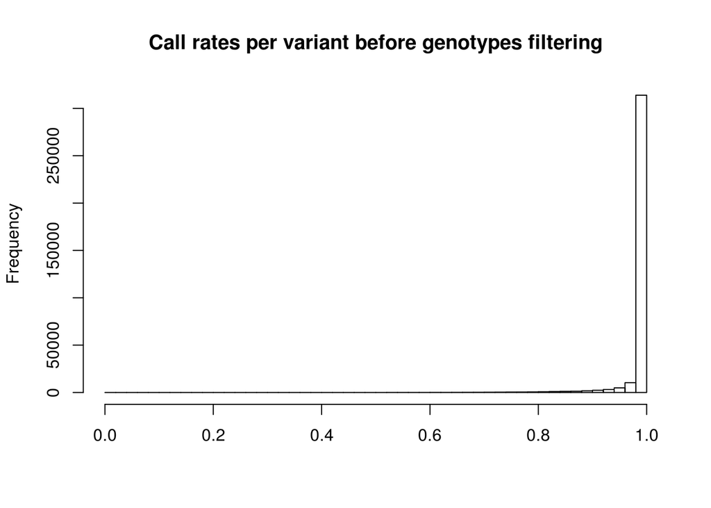

```r
# Call rates per variant before filtering
x <- ncol(gt.mx)
y <- apply(gt.mx,1,function(z){1-sum(is.na(z))/x})
hist(y, breaks=50, xlab=NULL, main="Call rates per variant before genotypes filtering")
```

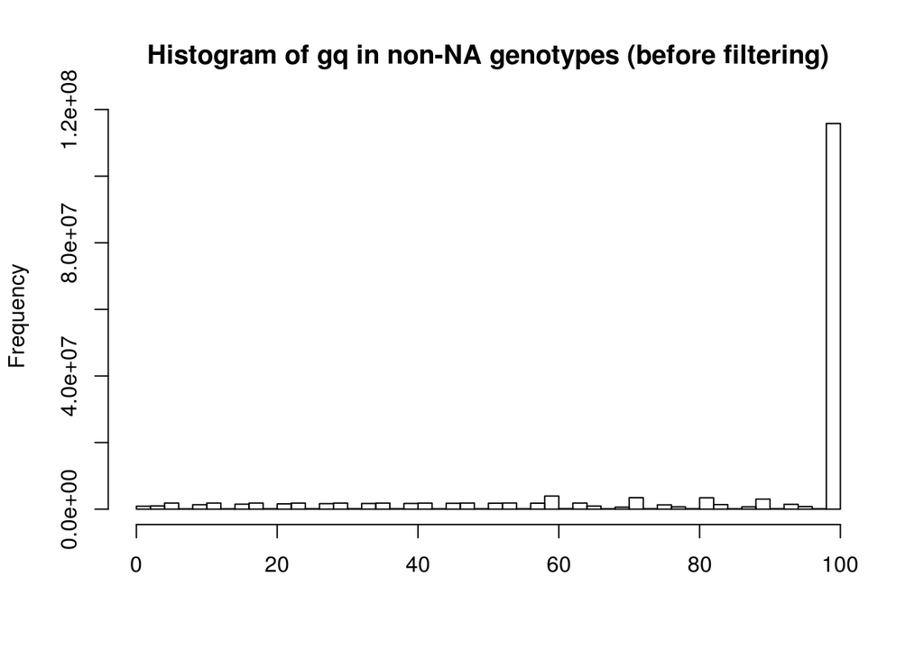

```r
# Histogram of gq  before filtering (when gt is not NA !)
hist(gq.mx[!is.na(gt.mx)], breaks=50, main="Histogram of gq in non-NA genotypes (before filtering)", xlab=NULL)
```

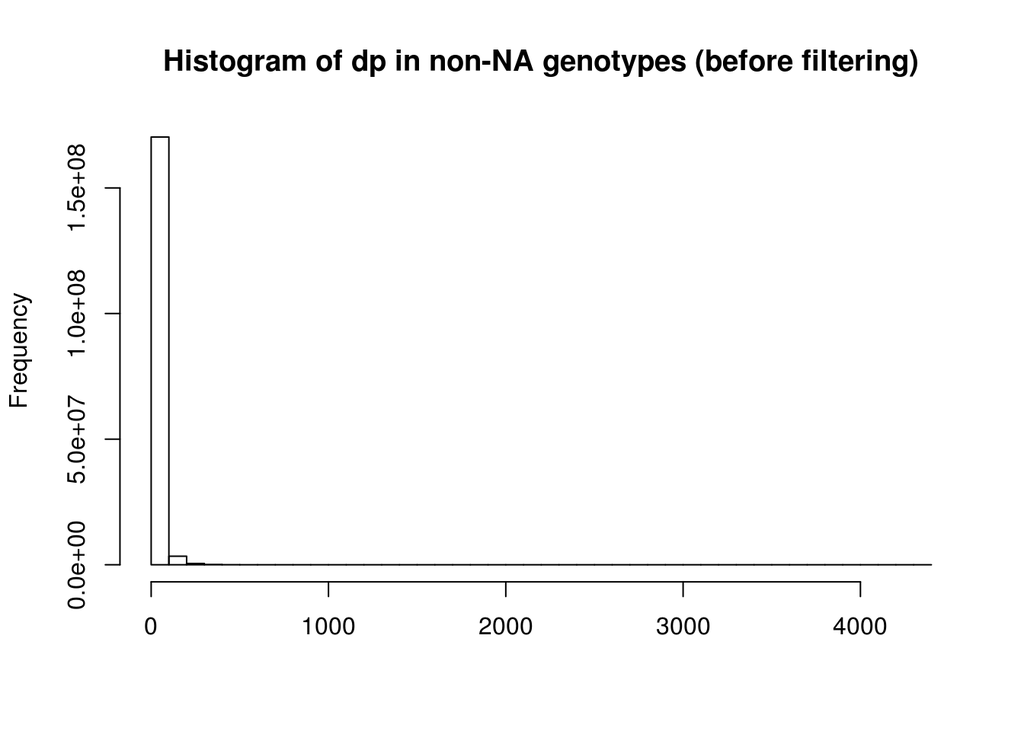

```r
# Histogram of dp before filtering (when gt is not NA !)
hist(dp.mx[!is.na(gt.mx)], breaks=50, main="Histogram of dp in non-NA genotypes (before filtering)", xlab=NULL)
```

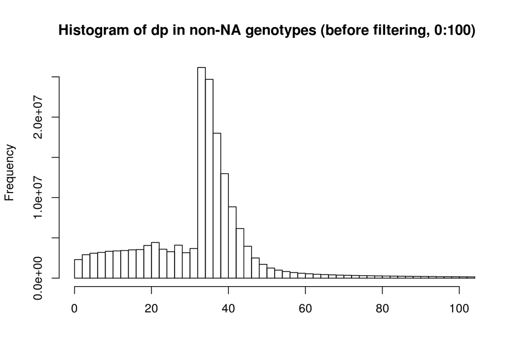

```r
hist(dp.mx[!is.na(gt.mx)], breaks=2500, xlim=c(0,100), main="Histogram of dp in non-NA genotypes (before filtering, 0:100)", xlab=NULL)
```

```r
# Clean-up
rm(x,y)
```

# filter_out_low_gq

```r
# num of genotypes to be removed
sum(gq.mx < min.gq, na.rm=TRUE)
```

```
## [1] 10376595
```

```r
# Fraction of non-NA genotypes to be removed
sum(gq.mx < min.gq, na.rm=TRUE)/sum(!is.na(gq.mx)) # ~6%
```

```
## [1] 0.0595757
```

```r
# Apply filter (to gt only !)
NA -> gt.mx[ gq.mx < min.gq ]

# Clean up
rm(min.gq)
```

# explore_data_after_gq_filtering

```r
dim(gt.mx)
```

```
## [1] 343824    512
```

```r
# Fraction of NA genotypes after gq filtering
sum(is.na(gt.mx))/(dim(gt.mx)[1]*dim(gt.mx)[2]) # ~7%
```

```
## [1] 0.06867647
```

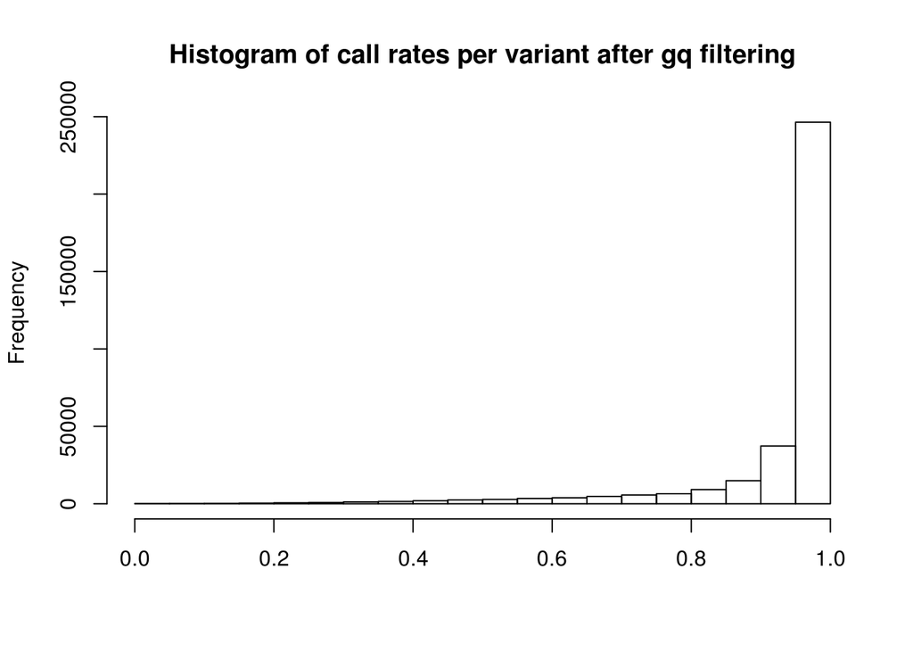

```r
# Call rates per variant after gq filtering
x <- ncol(gt.mx)
y <- apply(gt.mx, 1, function(z){1-sum(is.na(z))/x})
hist(y, xlab=NULL, main="Histogram of call rates per variant after gq filtering")
```

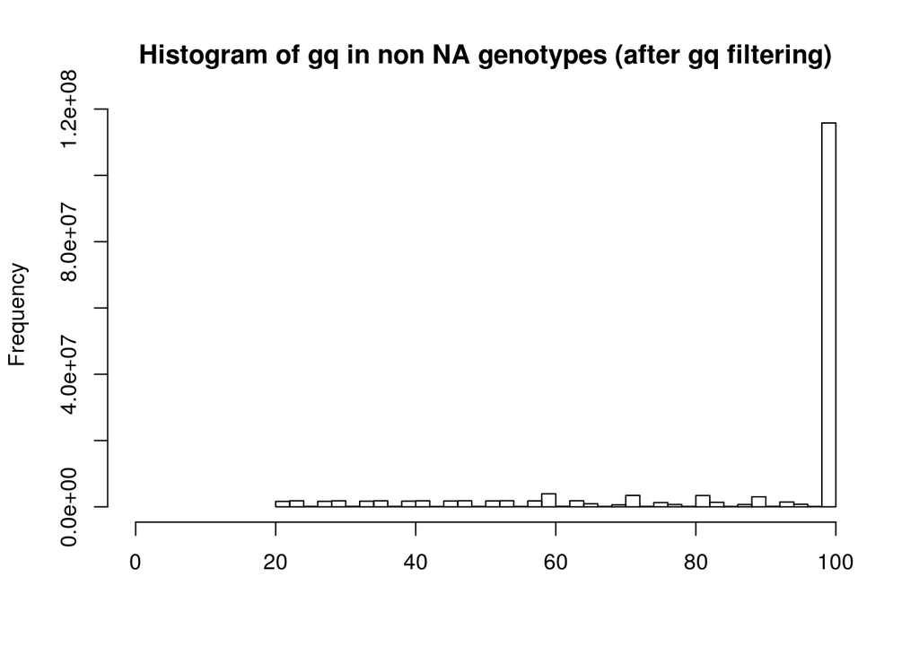

```r
# Histogram of gq  after gq filtering (when gt is not NA !)
hist(gq.mx[!is.na(gt.mx)], xlim=c(0,100), breaks=50, main="Histogram of gq in non NA genotypes (after gq filtering)", xlab=NULL)
```

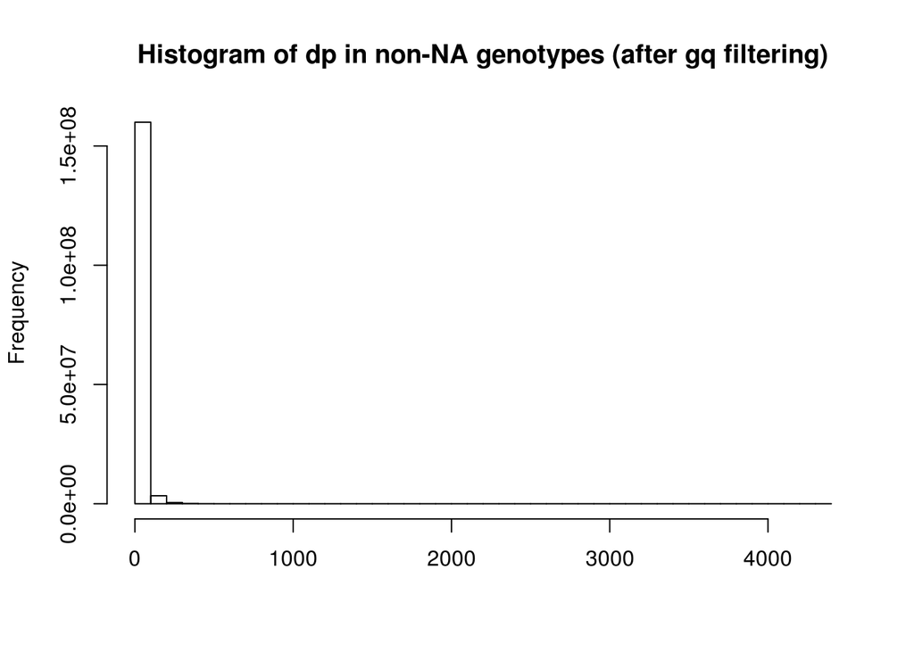

```r
# Histogram of dp after gt filtering (when gt is not NA !)
hist(dp.mx[!is.na(gt.mx)], breaks=50, main="Histogram of dp in non-NA genotypes (after gq filtering)", xlab=NULL)
```

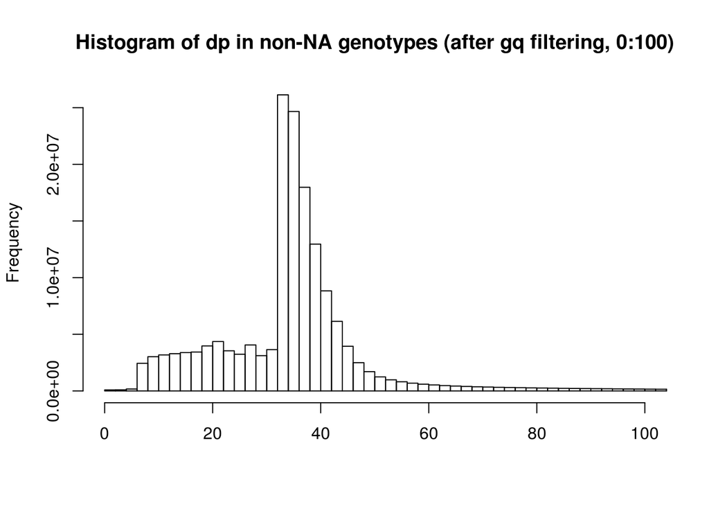

```r
hist(dp.mx[!is.na(gt.mx)], xlim=c(0,100), breaks=2500, main="Histogram of dp in non-NA genotypes (after gq filtering, 0:100)", xlab=NULL)
```

```r
# Clean up
rm(x, y)
```

# filter_out_high_dp

put NA to genotypes where dp > 500 : removes <<1% of non-NA genotypes

```r
# num of genotypes to be removed
sum(dp.mx > max.dp, na.rm=TRUE)
```

```
## [1] 21121
```

```r
# Fraction of genotypes to be removed (appr)
sum(dp.mx > max.dp, na.rm=TRUE)/sum(!is.na(gq.mx)) # <<1%
```

```
## [1] 0.0001212631
```

```r
# Apply filter (to gt only !)
NA -> gt.mx[ dp.mx > max.dp ]

# Clean up
rm(max.dp)
```

# explore_data_after_gq_dp_filtering

```r
dim(gt.mx)
```

```
## [1] 343824    512
```

```r
# Fraction of NA genotypes after filtering
sum(is.na(gt.mx))/(dim(gt.mx)[1]*dim(gt.mx)[2]) # ~7%
```

```
## [1] 0.06878846
```

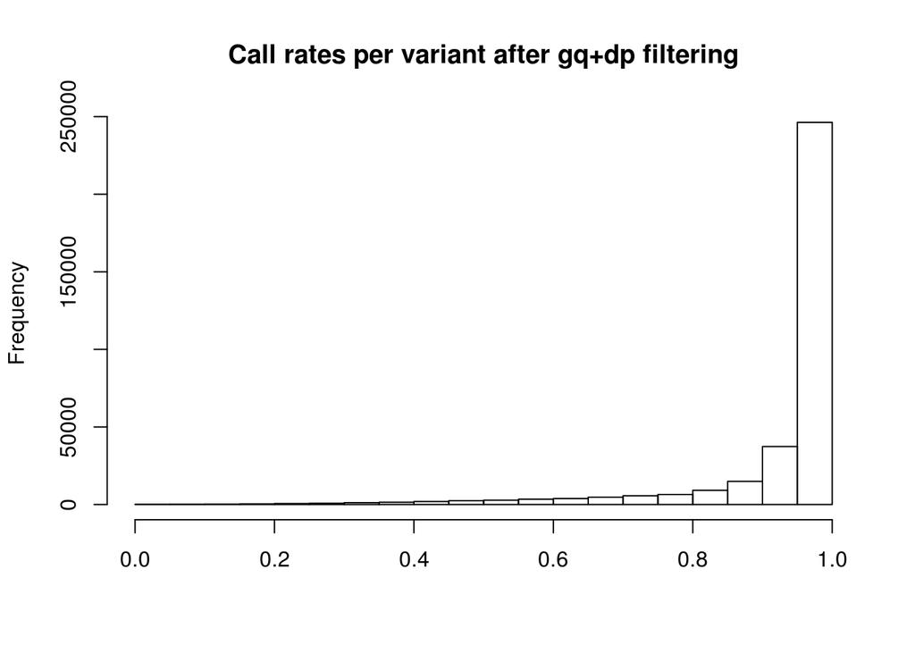

```r
# Call rates per variant after gq filtering
x <- ncol(gt.mx)
y <- apply(gt.mx, 1, function(z){1-sum(is.na(z))/x})
hist(y, xlab=NULL, main="Call rates per variant after gq+dp filtering")
```

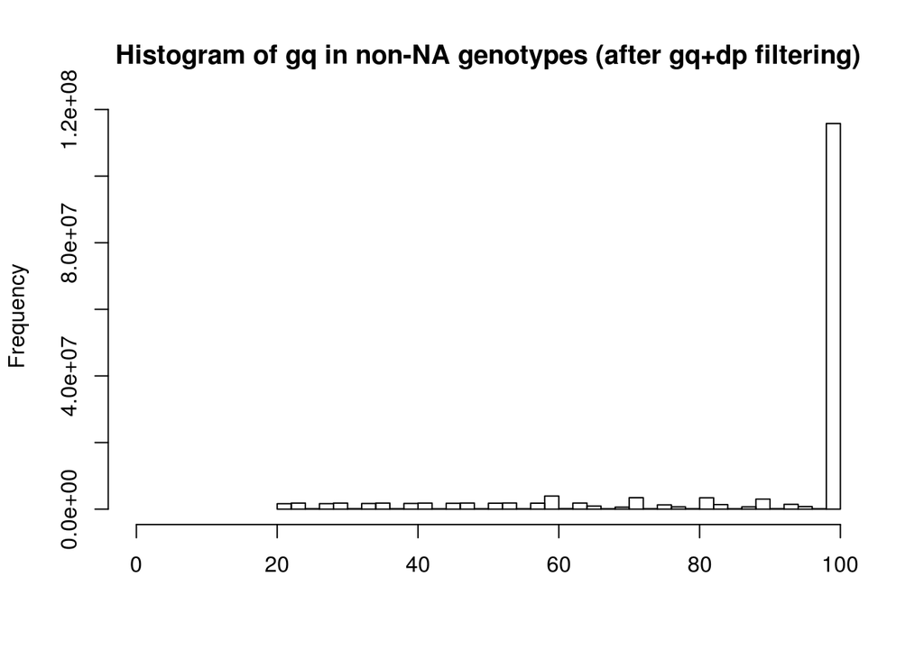

```r
# Histogram of gq  after gq+dp filtering (when gt is not NA !)
hist(gq.mx[!is.na(gt.mx)], xlim=c(0,100), breaks=50, main="Histogram of gq in non-NA genotypes (after gq+dp filtering)", xlab=NULL)
```

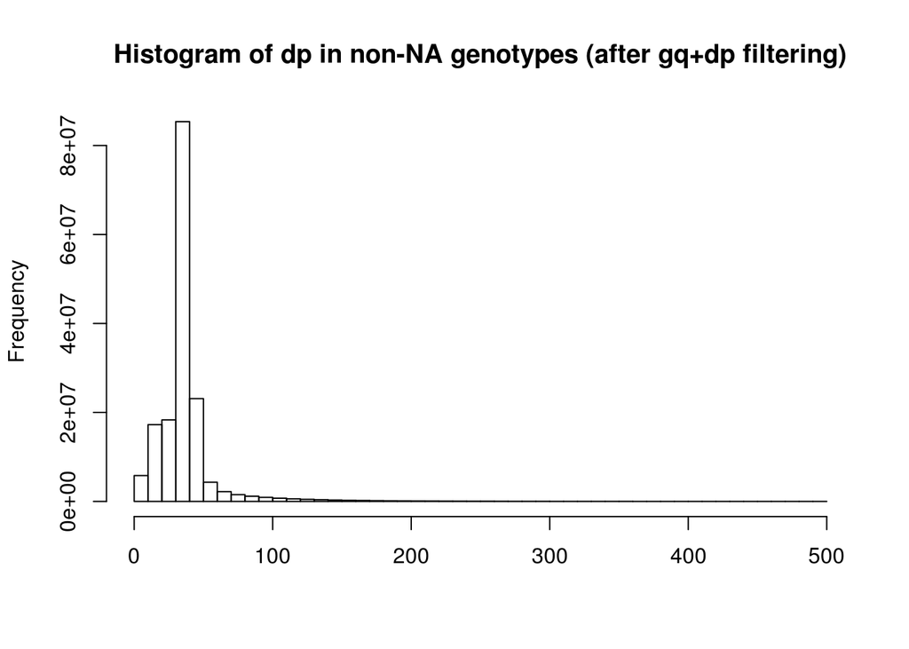

```r
# Histogram of dp after gt filtering (when gt is not NA !)
hist(dp.mx[!is.na(gt.mx)], breaks=50, main="Histogram of dp in non-NA genotypes (after gq+dp filtering)", xlab=NULL)
```

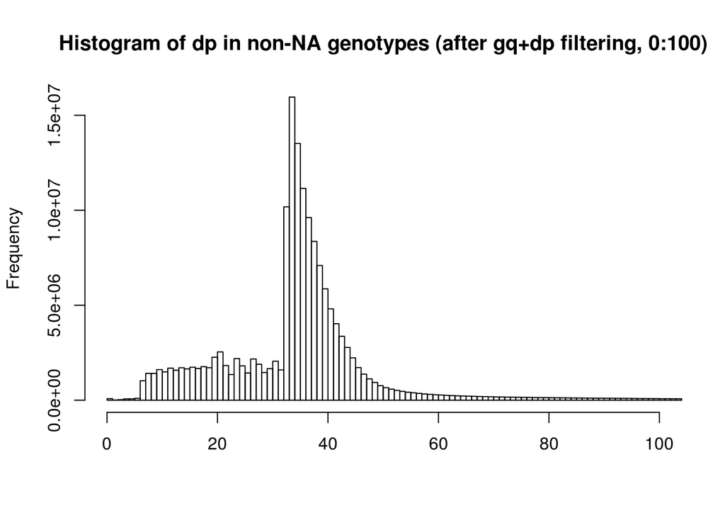

```r
hist(dp.mx[!is.na(gt.mx)], xlim=c(0,100), breaks=500, main="Histogram of dp in non-NA genotypes (after gq+dp filtering, 0:100)", xlab=NULL)
```

```r
# Clean up
rm(x, y)
```

# filter_variants_by_final_call_rate

Remove variants with call rate < 85% after the gemnotypes filtering:  
removes 45,214 (~13%) variants (343,824 -> 298,610)

```r
# Estimate the proportion of variants to be removed
x <- ncol(gt.mx)
y <- apply(gt.mx, 1, function(z){1-sum(is.na(z))/x})
y[1:7]
```

```
## Var000000001 Var000000002 Var000000003 Var000000004 Var000000005
##    0.9824219    0.9902344    0.8398438    0.5351562    0.7011719
## Var000000006 Var000000007
##    0.7480469    0.7949219
```

```r
var.retained <- y >= min.call.rate
sum(var.retained) # 298,610
```

```
## [1] 298610
```

```r
1 - sum(var.retained)/nrow(gt.mx) # ~13%
```

```
## [1] 0.1315033
```

```r
# Remove variants with loaw call rates
gt.mx <- gt.mx[ var.retained, ]
dp.mx <- dp.mx[ var.retained, ]
gq.mx <- gq.mx[ var.retained, ]
vv.df <- vv.df[ var.retained, ]
kgen.df <- kgen.df[ var.retained, ]
exac.df <- exac.df[ var.retained, ]

# Clean-up
rm(min.call.rate, var.retained, x, y)
```

# remove_variants_with_the_uniform_genotypes_accross_all_samples

Remove 51,156 variants: 298,610 -> 247,454  
Some of the removed variants were detected in NFE only  
In some variants the diverse genotypes were removed during the above filtering

```r
# Check that there is no all-NA variants
non_NA_count.udf <- function(x){sum(!is.na(x))}
all_NA <- apply(gt.mx, 1, non_NA_count.udf) == 0
sum(all_NA) # 0
```

```
## [1] 0
```

```r
# Function to detect uniform numeric vector
uniform_vector.udf <- function(x){
  if(min(x, na.rm=TRUE) == max(x, na.rm=TRUE)){return(TRUE)} else {return(FALSE)}}

# Variants with uniform genotypes accross all samples
uniform_genotypes <- apply(gt.mx, 1, uniform_vector.udf)
summary(uniform_genotypes)
```

```
##    Mode   FALSE    TRUE
## logical  247454   51156
```

```r
sum(uniform_genotypes)
```

```
## [1] 51156
```

```r
# Remove variants with uniform genotypes accross all samples
gt.mx <- gt.mx[!uniform_genotypes,]
gq.mx <- gq.mx[!uniform_genotypes,]
dp.mx <- dp.mx[!uniform_genotypes,]

vv.df <- vv.df[!uniform_genotypes,]
kgen.df <- kgen.df[!uniform_genotypes,]
exac.df <- exac.df[!uniform_genotypes,]

dim(gt.mx)
```

```
## [1] 247454    512
```

```r
dim(gq.mx)
```

```
## [1] 247454    512
```

```r
dim(dp.mx)
```

```
## [1] 247454    512
```

```r
dim(vv.df)
```

```
## [1] 247454     35
```

```r
dim(kgen.df)
```

```
## [1] 247454      9
```

```r
dim(exac.df)
```

```
## [1] 247454     48
```

```r
# Clean-up
rm(non_NA_count.udf, all_NA, uniform_vector.udf, uniform_genotypes)
```

# explore_data_after_gq_dp_cr_filtering

```r
dim(gt.mx)
```

```
## [1] 247454    512
```

```r
# Fraction of NA genotypes after filtering
sum(is.na(gt.mx))/(dim(gt.mx)[1]*dim(gt.mx)[2]) # ~3%
```

```
## [1] 0.02518036
```

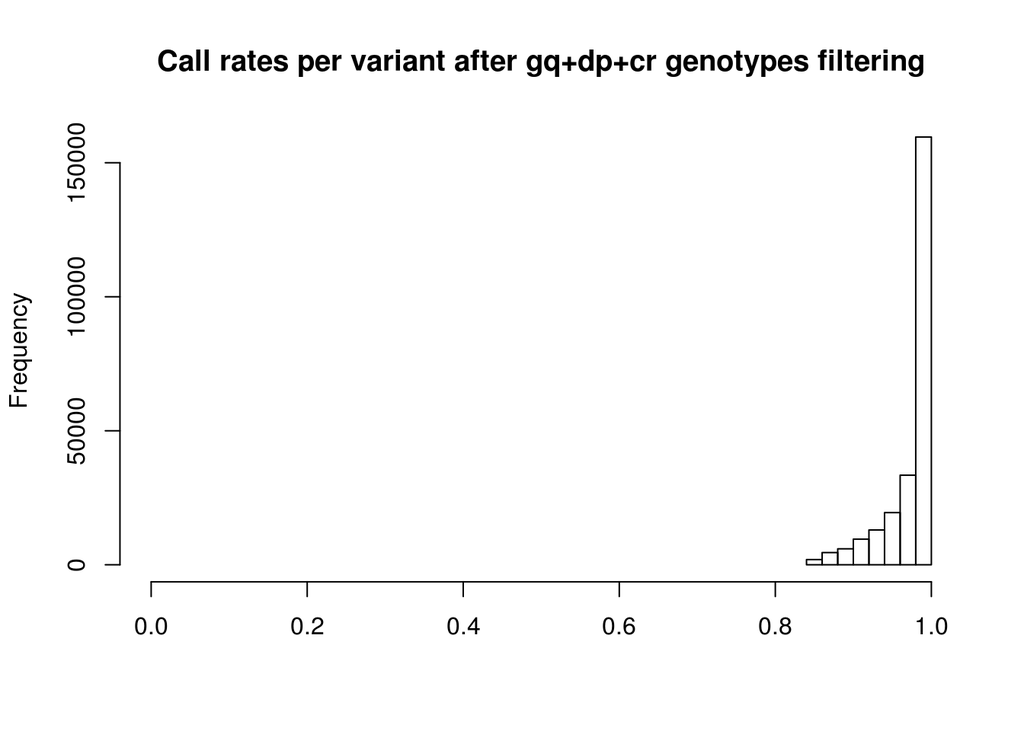

```r
# Call rates per variant after filtering
x <- ncol(gt.mx)
y <- apply(gt.mx,1,function(z){1-sum(is.na(z))/x})
hist(y, xlim=c(0,1), breaks=10, xlab=NULL, main="Call rates per variant after gq+dp+cr genotypes filtering")
```

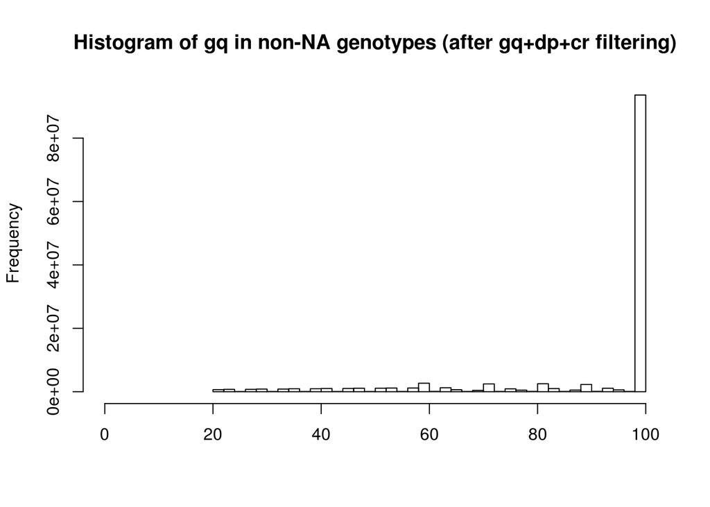

```r
# Histogram of gq  after filtering (when gt is not NA !)
hist(gq.mx[!is.na(gt.mx)], xlim=c(0,100), breaks=50, main="Histogram of gq in non-NA genotypes (after gq+dp+cr filtering)", xlab=NULL)
```

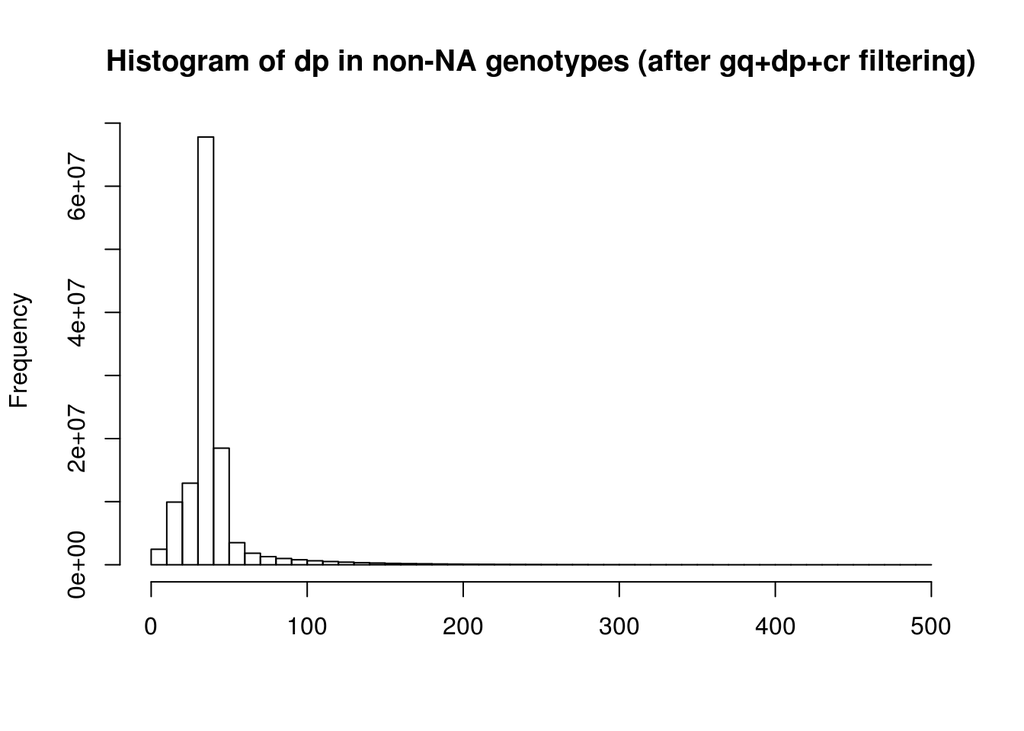

```r
# Histogram of dp  after filtering (when gt is not NA !)
hist(dp.mx[!is.na(gt.mx)], breaks=50, main="Histogram of dp in non-NA genotypes (after gq+dp+cr filtering)", xlab=NULL)
```

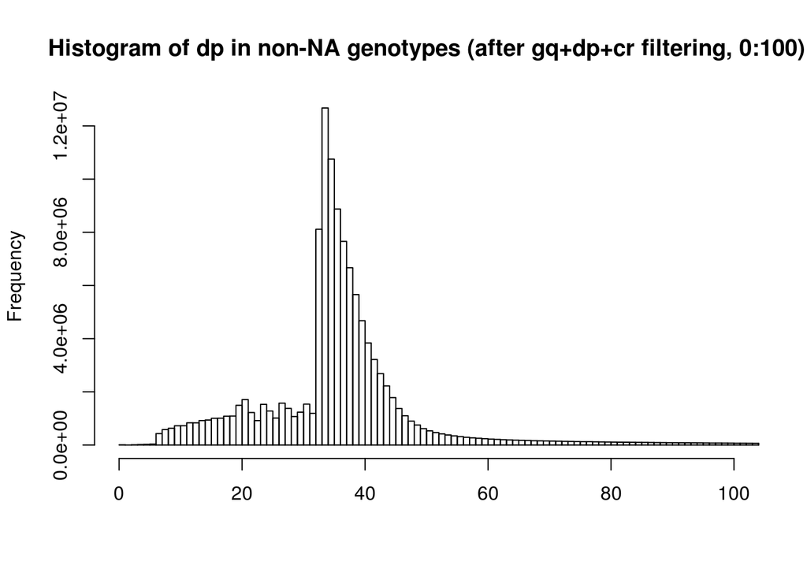

```r
hist(dp.mx[!is.na(gt.mx)], breaks=500, xlim=c(0,100), main="Histogram of dp in non-NA genotypes (after gq+dp+cr filtering, 0:100)", xlab=NULL)
```

```r
# Mean GQ and DP in retained data
mean(gq.mx, na.rm=TRUE)
```

```
## [1] 88.12073
```

```r
mean(dp.mx, na.rm=TRUE)
```

```
## [1] 38.5525
```

```r
# Clean-up
rm(x, y, gq.mx, dp.mx)
```

# data_summary

```r
dim(gt.mx)
```

```
## [1] 247454    512
```

```r
class(gt.mx)
```

```
## [1] "matrix"
```

```r
gt.mx[1:5,1:5]
```

```
##              P1_A01 P1_A02 P1_A03 P1_A04 P1_A05
## Var000000001      0      1      0      0      0
## Var000000002      0      0      0      0      0
## Var000000008      0      0     NA      0     NA
## Var000000020      0      0      0      0      0
## Var000000021      0      0      0      0      0
```

```r
dim(covar.df)
```

```
## [1] 498  34
```

```r
str(covar.df)
```

```
## 'data.frame':    498 obs. of  34 variables:
##  $ Subject_ID      : int  200054 200491 200565 200698 200958 201046 201558 201921 202026 202236 ...
##  $ setno           : int  382125 204356 360683 226881 357431 374980 201558 201921 213991 385058 ...
##  $ cc              : int  0 0 0 0 0 0 1 1 0 0 ...
##  $ chemo           : int  1 1 0 0 1 1 1 1 1 1 ...
##  $ hormone         : int  0 1 1 0 1 0 0 1 1 0 ...
##  $ chemo_hormone   : Factor w/ 5 levels "","both","chem",..: 3 2 4 5 2 3 3 2 2 3 ...
##  $ chemo_self_mra  : int  1 1 0 0 1 1 1 1 1 1 ...
##  $ hormone_self_mra: int  0 1 1 0 1 0 0 1 1 0 ...
##  $ treatment       : int  1 1 1 0 1 1 1 1 1 1 ...
##  $ ID              : int  2 6 7 9 11 12 16 22 24 26 ...
##  $ labid           : Factor w/ 498 levels "id200054","id200491",..: 1 2 3 4 5 6 7 8 9 10 ...
##  $ status          : int  0 0 0 0 0 0 1 1 0 0 ...
##  $ status2         : int  0 0 0 0 0 0 1 1 0 0 ...
##  $ offset          : num  6.41 5.82 5.61 4.03 4.77 ...
```

[output cut: 20 more lines]

```r
covar.df[1:5,1:5]
```

```
##   Subject_ID  setno cc chemo hormone
## 1     200054 382125  0     1       0
## 2     200491 204356  0     1       1
## 3     200565 360683  0     0       1
## 4     200698 226881  0     0       0
## 5     200958 357431  0     1       1
```

```r
dim(samples.df)
```

```
## [1] 512   4
```

```r
str(samples.df)
```

```
## 'data.frame':    512 obs. of  4 variables:
##  $ wes_id   : Factor w/ 512 levels "P1_A01","P1_A02",..: 1 2 3 4 5 6 7 8 9 10 ...
##  $ gwas_id  : Factor w/ 510 levels "id200054","id200491",..: 14 405 315 264 67 121 326 251 281 141 ...
##  $ merged_id: Factor w/ 512 levels "P1_A01_id203568",..: 1 2 3 4 5 6 7 8 9 10 ...
##  $ filter   : Factor w/ 5 levels "duplicate","low_concordance",..: 5 5 5 5 5 5 5 5 5 5 ...
```

```r
samples.df[1:5,]
```

```
##   wes_id  gwas_id       merged_id filter
## 1 P1_A01 id203568 P1_A01_id203568   pass
## 2 P1_A02 id357807 P1_A02_id357807   pass
## 3 P1_A03 id325472 P1_A03_id325472   pass
## 4 P1_A04 id304354 P1_A04_id304354   pass
## 5 P1_A05 id222648 P1_A05_id222648   pass
```

```r
dim(demographics.df)
```

```
## [1] 505  91
```

```r
str(demographics.df)
```

```
## 'data.frame':    505 obs. of  91 variables:
##  $ Subject_ID            : Factor w/ 503 levels "200054","200491",..: 1 2 3 4 5 6 7 8 9 10 ...
##  $ ID.x                  : num  2 6 7 9 11 12 NA NA 24 26 ...
##  $ labid.x               : Factor w/ 498 levels "15582015","19212019",..: 6 7 8 9 10 11 NA NA 12 13 ...
##  $ Eigen_1.x             : num  -0.0079 -0.01062 -0.00539 -0.00906 -0.01094 ...
##  $ Eigen_2.x             : num  0.0055 0.00414 0.00302 0.00301 0.0023 ...
##  $ Eigen_3.x             : num  -0.02171 0.01254 0.00368 -0.00655 -0.01389 ...
##  $ Eigen_4.x             : num  0.00356 -0.00787 -0.01496 -0.01256 -0.00501 ...
##  $ Eigen_5.x             : num  0.00135 -0.0291 0.00391 0.01357 -0.00526 ...
##  $ Phase                 : num  1 1 1 1 1 1 NA NA 1 1 ...
##  $ setno.x               : num  382125 204356 360683 226881 357431 ...
##  $ cc.x                  : int  0 0 0 0 0 0 NA NA 0 0 ...
##  $ rstime                : num  7.42 9.75 6.09 6.25 9.34 7 NA NA 6.09 8.66 ...
##  $ registry.x            : Factor w/ 7 levels "","de","IA","IR",..: 2 4 4 7 7 5 NA NA 3 2 ...
##  $ race.x                : num  0 0 0 0 0 0 NA NA 0 0 ...
```

[output cut: 77 more lines]

```r
demographics.df[1:5,1:5]
```

```
##   Subject_ID ID.x  labid.x    Eigen_1.x   Eigen_2.x
## 1     200054    2 id200054 -0.007897666 0.005498053
## 2     200491    6 id200491 -0.010615326 0.004141289
## 3     200565    7 id200565 -0.005393813 0.003017045
## 4     200698    9 id200698 -0.009061714 0.003010147
## 5     200958   11 id200958 -0.010936549 0.002295868
```

```r
dim(phenotypes_update.df)
```

```
## [1] 13 22
```

```r
str(phenotypes_update.df)
```

```
## 'data.frame':    13 obs. of  22 variables:
##  $ gwas_id       : chr  "id319270" "id298378" "id271981" "id301570" ...
##  $ wes_id        : chr  "P1_C02" "P1_C04" "P1_C06" "P1_C11" ...
##  $ cc            : int  0 0 0 0 1 0 1 1 0 0 ...
##  $ setno         : int  227587 243637 332699 247333 204830 204830 310424 247333 398607 201558 ...
##  $ family_history: int  1 1 1 0 1 0 1 1 0 0 ...
##  $ age_dx        : int  30 30 31 30 24 23 31 33 49 40 ...
##  $ age_ref       : int  39 33 32 34 28 27 32 37 54 47 ...
##  $ rstime        : num  9.08 3.17 2.09 4.5 3.83 3.83 1.33 4.5 5.16 7.25 ...
##  $ Eigen_1       : num  -0.01369 -0.00753 -0.00687 -0.00363 -0.01057 ...
##  $ Eigen_2       : num  0.00615 0.00853 0.00138 0.00428 0.00317 ...
##  $ Eigen_3       : num  -0.00474 -0.01256 0.00329 0.03749 -0.00716 ...
##  $ Eigen_4       : num  -0.00596 0.00849 -0.01233 -0.02952 -0.00024 ...
##  $ Eigen_5       : num  -0.01219 0.01074 -0.0138 -0.0202 -0.00147 ...
##  $ stage         : int  1 1 2 2 2 1 2 1 1 1 ...
##  $ er1           : num  0 1 0 1 0 1 1 NA 1 NA ...
##  $ pr1           : num  0 1 NA 1 0 1 0 NA 1 NA ...
##  $ hist_cat      : chr  "other carcinoma" "ductal" "ductal" "ductal" ...
##  $ hormone       : num  0 0 0 0 0 0 0 0 NA 0 ...
##  $ chemo_cat     : chr  "CMF" "no" "Oth" "no" ...
##  $ br_xray       : int  1 0 0 0 0 1 0 1 0 1 ...
##  $ br_xray_dose  : num  1.1 0 0 0 0 1.2 0 1.9 0 0.86 ...
##  $ num_preg      : int  2 0 1 1 1 0 0 1 1 0 ...
```

```r
phenotypes_update.df[1:5,1:5]
```

```
##    gwas_id wes_id cc  setno family_history
## 1 id319270 P1_C02  0 227587              1
## 2 id298378 P1_C04  0 243637              1
## 3 id271981 P1_C06  0 332699              1
## 4 id301570 P1_C11  0 247333              0
## 5 id204830 P1_E10  1 204830              1
```

```r
dim(BRCA1_BRCA2_PALB2_cases.df)
```

```
## [1] 11 12
```

```r
str(BRCA1_BRCA2_PALB2_cases.df)
```

```
## 'data.frame':    11 obs. of  12 variables:
##  $ Cases_wes_id : Factor w/ 11 levels "P1_A09","P1_C02",..: 1 2 3 4 5 6 7 8 9 10 ...
##  $ Cases_gwas_id: Factor w/ 11 levels "id204830","id247333",..: 8 9 3 1 6 2 4 11 5 7 ...
##  $ SYMBOL       : Factor w/ 3 levels "BRCA1","BRCA2",..: 1 3 1 1 2 1 2 2 3 3 ...
##  $ TYPE         : Factor w/ 2 levels "INDEL","SNP": 2 1 2 2 2 1 1 1 2 2 ...
##  $ CHROM        : int  17 16 17 17 13 17 13 13 16 16 ...
##  $ POS.GRCh37   : int  41256985 23641422 41243800 41258504 32936732 41276044 32914437 32914437 23625324 23634452 ...
##  $ REF          : Factor w/ 6 levels "A","C","G","GT",..: 5 6 2 1 3 1 4 4 2 2 ...
##  $ ALT          : Factor w/ 5 levels "A","ACT","C",..: 3 5 1 3 3 2 4 4 4 4 ...
##  $ rs_id        : Factor w/ 9 levels "rs28897672","rs28897686",..: 7 5 2 1 8 6 9 9 4 3 ...
##  $ Consequence  : Factor w/ 6 levels "frameshift_variant",..: 2 1 6 3 3 1 1 1 5 4 ...
##  $ wes_var_id   : Factor w/ 9 levels "Var000223294",..: 7 5 6 8 2 9 1 1 3 4 ...
##  $ Note         : Factor w/ 2 levels "","Added for QC": NA NA 2 2 NA 2 NA NA NA NA ...
```

```r
BRCA1_BRCA2_PALB2_cases.df[1:5,1:5]
```

```
##        Cases_wes_id Cases_gwas_id SYMBOL  TYPE CHROM
## P1_A09       P1_A09      id310692  BRCA1   SNP    17
## P1_C02       P1_C02      id319270  PALB2 INDEL    16
## P1_C06       P1_C06      id271981  BRCA1   SNP    17
## P1_E10       P1_E10      id204830  BRCA1   SNP    17
## P1_F09       P1_F09      id287640  BRCA2   SNP    13
```

```r
dim(vv.df)
```

```
## [1] 247454     35
```

```r
str(vv.df)
```

```
## 'data.frame':    247454 obs. of  35 variables:
##  $ SplitVarID         : Factor w/ 343824 levels "Var000000001",..: 1 2 8 20 21 23 24 25 26 29 ...
##  $ TYPE               : Factor w/ 2 levels "INDEL","SNP": 1 2 2 2 2 2 2 2 2 2 ...
##  $ ID                 : Factor w/ 253381 levels "rs10000804","rs10000924",..: NA 234676 162750 NA 60822 179585 155441 54219 NA 54504 ...
##  $ CHROM              : Factor w/ 25 levels "1","10","11",..: 1 1 1 1 1 1 1 1 1 1 ...
##  $ POS                : int  664486 762330 871215 880461 880483 880917 881627 881825 881871 883883 ...
##  $ REF                : Factor w/ 2142 levels "A","AAAAAAAAAAAAAAAAAAAAAAAG",..: 1653 1044 539 539 1 1044 1044 539 1044 1575 ...
##  $ ALT                : Factor w/ 1297 levels "A","AAAAAAAAAAAAACT",..: 989 989 664 989 664 1 1 989 1 323 ...
##  $ QUAL               : num  35191 7081 2492 409 4866 ...
##  $ DP                 : int  49355 26720 16282 21946 22167 20632 24755 21397 20118 19662 ...
##  $ AS_VQSLOD          : num  1.57 7.04 20.08 15.78 7.12 ...
##  $ FILTER             : Factor w/ 1 level "PASS": 1 1 1 1 1 1 1 1 1 1 ...
##  $ AC                 : int  53 8 5 1 8 1 891 2 1 2 ...
##  $ AF                 : num  0.044 0.006221 0.003811 0.000731 0.005822 ...
##  $ AN                 : int  1206 1286 1312 1368 1374 1360 1412 1406 1406 1286 ...
```

[output cut: 21 more lines]

```r
vv.df[1:5,1:5]
```

```
##                SplitVarID  TYPE          ID CHROM    POS
## Var000000001 Var000000001 INDEL        <NA>     1 664486
## Var000000002 Var000000002   SNP  rs74045217     1 762330
## Var000000008 Var000000008   SNP  rs28419423     1 871215
## Var000000020 Var000000020   SNP        <NA>     1 880461
## Var000000021 Var000000021   SNP rs144656266     1 880483
```

```r
dim(kgen.df)
```

```
## [1] 247454      9
```

```r
str(kgen.df)
```

```
## 'data.frame':    247454 obs. of  9 variables:
##  $ SplitVarID : Factor w/ 343824 levels "Var000000001",..: 1 2 8 20 21 23 24 25 26 29 ...
##  $ kgen.AC    : int  NA NA NA NA 11 NA 2213 NA NA 1 ...
##  $ kgen.AN    : int  NA NA NA NA 5008 NA 5008 NA NA 5008 ...
##  $ kgen.AF    : num  NA NA NA NA 0.0022 ...
##  $ kgen.AFR_AF: num  NA NA NA NA 0.0008 NA 0.0643 NA NA 0 ...
##  $ kgen.AMR_AF: num  NA NA NA NA 0.0043 NA 0.438 NA NA 0.0014 ...
##  $ kgen.EAS_AF: num  NA NA NA NA 0 NA 0.624 NA NA 0 ...
##  $ kgen.EUR_AF: num  NA NA NA NA 0.007 ...
##  $ kgen.SAS_AF: num  NA NA NA NA 0 ...
```

```r
kgen.df[1:5,1:5]
```

```
##                SplitVarID kgen.AC kgen.AN    kgen.AF kgen.AFR_AF
## Var000000001 Var000000001      NA      NA         NA          NA
## Var000000002 Var000000002      NA      NA         NA          NA
## Var000000008 Var000000008      NA      NA         NA          NA
## Var000000020 Var000000020      NA      NA         NA          NA
## Var000000021 Var000000021      11    5008 0.00219649       8e-04
```

```r
dim(exac.df)
```

```
## [1] 247454     48
```

```r
str(exac.df)
```

```
## 'data.frame':    247454 obs. of  48 variables:
##  $ SplitVarID             : Factor w/ 343824 levels "Var000000001",..: 1 2 8 20 21 23 24 25 26 29 ...
##  $ exac_non_TCGA.AF       : num  NA 1.20e-02 NA 2.82e-05 1.42e-03 ...
##  $ exac_non_TCGA.AC       : int  NA 175 NA 3 151 2 59637 110 NA 16 ...
##  $ exac_non_TCGA.AN       : int  NA 14012 NA 106200 106186 106210 106210 106210 NA 106210 ...
##  $ exac_non_TCGA.AC_FEMALE: int  NA 59 NA 0 60 2 24874 55 NA 8 ...
##  $ exac_non_TCGA.AN_FEMALE: int  NA 3452 NA 44730 40654 45832 45636 45686 NA 45738 ...
##  $ exac_non_TCGA.AC_MALE  : int  NA 91 NA 3 91 0 34597 55 NA 8 ...
##  $ exac_non_TCGA.AN_MALE  : int  NA 8250 NA 59120 54094 60288 60090 60260 NA 60228 ...
##  $ exac_non_TCGA.AC_Adj   : int  NA 150 NA 3 151 2 59471 110 NA 16 ...
##  $ exac_non_TCGA.AN_Adj   : int  NA 11702 NA 103850 94748 106120 105726 105946 NA 105966 ...
##  $ exac_non_TCGA.AC_Hom   : int  NA 0 NA 0 2 0 17732 0 NA 0 ...
##  $ exac_non_TCGA.AC_Het   : int  NA 150 NA 3 147 2 24007 110 NA 16 ...
##  $ exac_non_TCGA.AC_Hemi  : int  NA NA NA NA NA NA NA NA NA NA ...
##  $ exac_non_TCGA.AC_AFR   : int  NA 85 NA 0 9 0 1225 2 NA 0 ...
```

[output cut: 34 more lines]

```r
exac.df[1:5,1:5]
```

```
##                SplitVarID exac_non_TCGA.AF exac_non_TCGA.AC
## Var000000001 Var000000001               NA               NA
## Var000000002 Var000000002        1.200e-02              175
## Var000000008 Var000000008               NA               NA
## Var000000020 Var000000020        2.825e-05                3
## Var000000021 Var000000021        1.422e-03              151
##              exac_non_TCGA.AN exac_non_TCGA.AC_FEMALE
## Var000000001               NA                      NA
## Var000000002            14012                      59
## Var000000008               NA                      NA
## Var000000020           106200                       0
## Var000000021           106186                      60
```

```r
# Check consistence of rownames
sum(rownames(gt.mx) != rownames(vv.df))
```

```
## [1] 0
```

```r
sum(rownames(gt.mx) != rownames(kgen.df))
```

```
## [1] 0
```

```r
sum(rownames(gt.mx) != rownames(exac.df))
```

```
## [1] 0
```

# save_data

```r
#base_folder="/analysis/mtgroup_share/users/alexey/wecare_only_08.17"
save.image(paste(base_folder, "results", "r02_filter_genotypes_and_variants_wecare_only.RData", sep="/"))
```

# final_section

```r
ls()
```

```
##  [1] "base_folder"                "BRCA1_BRCA2_PALB2_cases.df"
##  [3] "covar.df"                   "demographics.df"
##  [5] "exac.df"                    "gt.mx"
##  [7] "kgen.df"                    "phenotypes_update.df"
##  [9] "samples.df"                 "vv.df"
```

```r
Sys.time()
```

```
## [1] "2017-08-26 21:05:40 BST"
```